# Applied SFC modelling with R

Antoine Godin

03 August 2016

## Outline

- pdfetch
- PKSFC package
- SFC visualisation
- Direct Acyclical Graphs
- Sankey diagrams
- Shiny Applications
- Calibration procedures
- Theoretical steady/stationary states
- Empirical calibration
- Bank of England Model

## pdfecth

- Fetch Economic and Financial Time Series Data from Public Sources
- Package developped by Abiel Reinhart
- We will be using the `pdfetch_EUROSTAT` function

```r
?pdfetch_EUROSTAT
```

## Example 1: Net lending per sector, UK

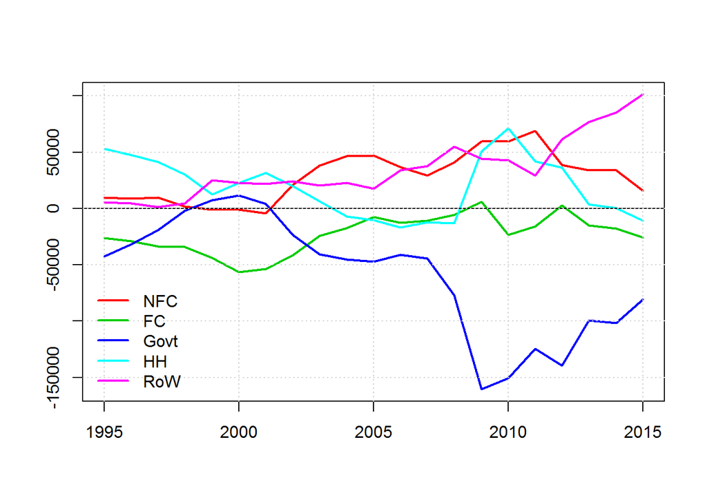

```r
# Specifying the name of the flows of interests
names<-c("B9")

# Downloading the data by specifying the various filters
UKdata_raw = pdfetch_EUROSTAT(flowRef = "nasa_10_nf_tr", UNIT="CP_MNAC",NA_ITEM=names, GEO="UK",
      DIRECT="PAID",SECTOR=c("S11","S12","S13","S14_S15","S2"))

# Transforming the obtained data into a data.frame
UKdata<-as.data.frame(UKdata_raw)

# Setting readable names
colnames(UKdata)<-c("NFC","FC","Govt","HH","RoW")

# Matricial plot
matplot(1995:2015,UKdata,lwd=2,type="l",lty=1,ylab="",xlab="",col=2:6)

# Adding the horizontal line
abline(h=0,col=1)

# Adding a grid
grid()

# Adding a legend
legend("bottomleft",col=c(2:6),lwd=2,lty=1,legend=c("NFC","FC","Govt","HH","RoW"),bty='n')
```

## Example 2: Household income statement from 2014

```r
# Selecting the flows
names<-c("B5G","D5","D61","D62","D7","D8","B6G","P3","B8G","P5G","D9","NP","B9")

# Obtaining the data
EZdata_raw = pdfetch_EUROSTAT("nasa_10_nf_tr", UNIT="CP_MNAC",NA_ITEM=names, GEO="EU28",
        SECTOR=c("S14_S15"), TIME="2014")

# Transforming the data into a data.frame
EZdata<-as.data.frame(EZdata_raw)

# Automatic procedure to remove the non-interesting bit of the colnames
coln<-colnames(EZdata)
newcoln<-c()
HHdata<-c()

for(i in 1:length(coln)){
  name<-coln[i]
  tname<-strsplit(name,"\\.")[[1]]
  newname<-paste(tname[3:4],collapse=".")
  # If the column contains only NA, remove it from the dataset
  if(!is.na(EZdata[16,i])){
   newcoln<-c(newcoln,newname)
   HHdata<-c(HHdata,EZdata[16,i])
  }
}

# Creating a new dataset with only values 2014
HHdata<-as.data.frame(t(HHdata))
colnames(HHdata)<-newcoln

# Creating the aggregates
HHdata_1<-as.data.frame(c(HHdata$PAID.B5G,-HHdata$PAID.D5,-HHdata$PAID.D61+HHdata$RECV.D61,
      +HHdata$RECV.D62-HHdata$PAID.D62,-HHdata$PAID.D7+HHdata$RECV.D7,HHdata$PAID.B6G))
colnames(HHdata_1)<-"2014"
rownames(HHdata_1)<-c("Total Income","Taxes","Social Contributions","Social Benefits",
      "Other transfers","Gross Disposable Income")
kable(HHdata_1)
```

|  | 2014 |
| --- | --- |
| Total Income | 9851688 |
| Taxes | -1442130 |
| Social Contributions | -2425244 |
| Social Benefits | 2635931 |
| Other transfers | 109116 |
| Gross Disposable Income | 8729361 |

```r
HHdata_2<-as.data.frame(c(HHdata$PAID.B6G,-HHdata$PAID.P3,-HHdata$PAID.D8+HHdata$RECV.D8,
      HHdata$PAID.B8G))
colnames(HHdata_2)<-"2014"
rownames(HHdata_2)<-c("Gross Disposable Income","Consumption","Adjustments in Pensions",
      "Gross Savings")
kable(HHdata_2)
```

|  | 2014 |
| --- | --- |
| Gross Disposable Income | 8729361 |
| Consumption | -8012603 |
| Adjustments in Pensions | 201553 |
| Gross Savings | 918310 |

```r
HHdata_3<-as.data.frame(c(HHdata$PAID.B8G,-HHdata$PAID.P5G,-HHdata$PAID.D9+HHdata$RECV.D9,
      -HHdata$PAID.NP,HHdata$PAID.B9))

colnames(HHdata_3)<-"2014"
rownames(HHdata_3)<-c("Gross Savings","Gross Capital Formation","Capital Transfer",
      "Net Non-Produced NF Assets","Net Lending Position")
kable(HHdata_3)
```

|  | 2014 |
| --- | --- |
| Gross Savings | 918310 |
| Gross Capital Formation | -716849 |
| Capital Transfer | 14213 |
| Net Non-Produced NF Assets | 6360 |
| Net Lending Position | 222034 |

## PKSFC package

- Allowing to simulate SFC models in an open source environment}
- Still preliminary
- Only one numerical solver: Gauss-Seidel algorithm (Kinsella and O’Shea 2010)
- github.com/s120/pksfc
- Technical aspect
- R package
- EViews translator
- Read equation files
- Build model from console
- Visualisation/Design tools and helpers

## Installing the dependent libraries and the package

You need to install all the required libraries This is for traditional libraries

```r
install.packages("expm")
install.packages("igraph")
```

For non-conventional libraries, such as the one need to visualize Direct Acyclical Graphs (DAG), you need to do the following

```r
source("http://bioconductor.org/biocLite.R")
biocLite("Rgraphviz")
```

Finally you can then download the PKSFC package from github and install it locally

```r
install.packages("path/PKSFC_1.5.tar.gz", repos = NULL, type="source")
```

## Testing

Now we’re ready to load the package:

```r
library(PKSFC)
```

1. Load SIM (download SIM.txt from Github)

```r
sim<-sfc.model("SIM.txt",modelName="SIMplest model from chapter 3 of Godley and Lavoie (2007)")
```

2. Simulate the model

```r
datasim<-simulate(sim)
```

3. replicate figure 3.2 of page 73.

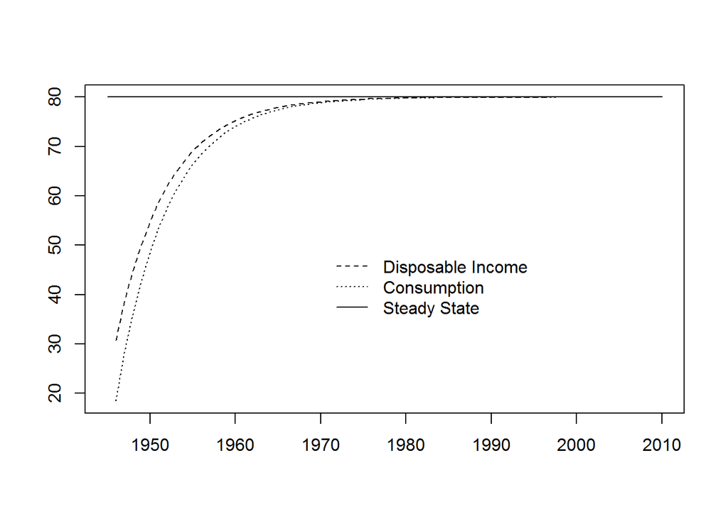

```r
plot(sim$time,datasim$baseline[,"Yd"],type="l", xlab="", ylab="", lty=2,
     ylim=range(datasim$baseline[,c("Yd","C")],na.rm=T))
lines(sim$time,datasim$baseline[,"C"],lty=3)
lines(sim$time,vector(length=length(sim$time))+datasim$baseline["2010","C"])
legend(x=1970,y=50,legend=c("Disposable Income","Consumption","Steady State"),lty=c(2,3,1),bty="n")
```

## How does it work?

- The package parses a text file containing the equations
- It generates an internal representation of the model
- It checks the internal consistency of the model, the calibration
- Allows to simulate the model using a linear solver, the Gauss-Seidel Algorithm

## Source code of SIM

```r
#1. EQUATIONS
C = C
G = G
T = T
N = N
Yd = W*N - T
T = theta*W*N
C = alpha1*Yd + alpha2*H_h(-1)
H = H(-1) + G - T
H_h = H_h(-1) + Yd - C
Y = C + G
N = Y/W
#2. PARAMETERS
alpha1=0.6
alpha2=0.4
theta=0.2
#EXOGENOUS
G=20
W=1
#INITIAL VALUES
H=0
H_h=0
#3. Timeline
timeline 1945 2010
```

## A few important points regarding the model source code:

- The first line of the code should be a comment line (starting with `#`)
- The file should not contain any empty lines.
- You should avoid naming your variables with reserved names in R such as ‘in’ or ‘max’.
- There should be only one equation per line.
- There should be only one variable on the left hand side of the equation.
- You can use R functions such as min, max, or logical operators such as > or <=. In the case the logical operatur returns true, the numeric value will be one. Thus `(100>10)` will return `1`.
- The lag operator is represented by `(-x)` where `x` is the lag.
- You can add as many comments, using the `#` character at the begining of the line. Each comment exactly above an equation will be considered as the description of the equation and will be stored in the internal representation of the sfc model object.

## Internal representation

```r
print(sim)
```

```
## $name
## [1] "SIMplest model from chapter 3 of Godley and Lavoie (2007)"
##
## $simulated
## [1] FALSE
##
## $variables
##       name     initial value description
##  [1,] "Yd"     NA            "1. EQUATIONS"
##  [2,] "T"      NA            ""
##  [3,] "C"      NA            ""
##  [4,] "H"      "0"           ""
##  [5,] "H_h"    "0"           ""
##  [6,] "Y"      NA            ""
##  [7,] "N"      NA            ""
##  [8,] "alpha1" "0.6"         "2. PARAMETERS"
##  [9,] "alpha2" "0.4"         ""
## [10,] "theta"  "0.2"         ""
## [11,] "G"      "20"          "EXOGENOUS"
## [12,] "W"      "1"           ""
##
## $endogenous
##      name  initial value lag description
## [1,] "Yd"  NA            "0" "1. EQUATIONS"
## [2,] "T"   NA            "0" ""
## [3,] "C"   NA            "0" ""
## [4,] "H"   "0"           "1" ""
## [5,] "H_h" "0"           "1" ""
## [6,] "Y"   NA            "0" ""
## [7,] "N"   NA            "0" ""
##
## $equations
##      endogenous value equation                 description
## [1,] "Yd"             "W*N-T"                  "1. EQUATIONS"
## [2,] "T"              "theta*W*N"              ""
## [3,] "C"              "alpha1*Yd+alpha2*H_h_1" ""
## [4,] "H"              "H_1+G-T"                ""
## [5,] "H_h"            "H_h_1+Yd-C"             ""
## [6,] "Y"              "C+G"                    ""
## [7,] "N"              "Y/W"                    ""
```

[output cut: 10 more lines]

```
## Yd   0 1 0 0   0 0 1
## T    0 0 0 0   0 0 1
## C    1 0 0 0   0 0 0
## H    0 1 0 0   0 0 0
## H_h  1 0 1 0   0 0 0
## Y    0 0 1 0   0 0 0
## N    0 0 0 0   0 1 0
##
## $blocks
## $blocks[[1]]
## [1] 2 3 4 6 7 1 5
##
##
## attr(,"class")
## [1] "sfc"
```

## Output data structure

- Output is a list of matrix where each element of the list are a scenario
- baseline
- scenario_i

```r
kable(datasim$baseline)
```

|  | Yd | T | C | H | H_h | Y | N | alpha1 | alpha2 | theta | G | W | iter block 1 |
| --- | --- | --- | --- | --- | --- | --- | --- | --- | --- | --- | --- | --- | --- |
| 1945 | NA | NA | NA | 0.00000 | 0.00000 | NA | NA | 0.6 | 0.4 | 0.2 | 20 | 1 | 0 |
| 1946 | 30.76923 | 7.692308 | 18.46154 | 12.30769 | 12.30769 | 38.46154 | 38.46154 | 0.6 | 0.4 | 0.2 | 20 | 1 | 293 |
| 1947 | 38.34320 | 9.585799 | 27.92899 | 22.72189 | 22.72189 | 47.92899 | 47.92899 | 0.6 | 0.4 | 0.2 | 20 | 1 | 269 |
| 1948 | 44.75193 | 11.187984 | 35.93992 | 31.53391 | 31.53391 | 55.93992 | 55.93992 | 0.6 | 0.4 | 0.2 | 20 | 1 | 263 |
| 1949 | 50.17471 | 12.543678 | 42.71839 | 38.99023 | 38.99023 | 62.71839 | 62.71839 | 0.6 | 0.4 | 0.2 | 20 | 1 | 258 |
| 1950 | 54.76322 | 13.690805 | 48.45402 | 45.29943 | 45.29943 | 68.45402 | 68.45402 | 0.6 | 0.4 | 0.2 | 20 | 1 | 254 |
| 1951 | 58.64580 | 14.661450 | 53.30725 | 50.63798 | 50.63798 | 73.30725 | 73.30725 | 0.6 | 0.4 | 0.2 | 20 | 1 | 251 |
| 1952 | 61.93106 | 15.482766 | 57.41383 | 55.15521 | 55.15521 | 77.41383 | 77.41383 | 0.6 | 0.4 | 0.2 | 20 | 1 | 247 |
| 1953 | 64.71090 | 16.177725 | 60.88862 | 58.97749 | 58.97749 | 80.88862 | 80.88862 | 0.6 | 0.4 | 0.2 | 20 | 1 | 244 |
| 1954 | 67.06307 | 16.765767 | 63.82884 | 62.21172 | 62.21172 | 83.82884 | 83.82884 | 0.6 | 0.4 | 0.2 | 20 | 1 | 242 |
| 1955 | 69.05337 | 17.263341 | 66.31671 | 64.94838 | 64.94838 | 86.31671 | 86.31671 | 0.6 | 0.4 | 0.2 | 20 | 1 | 239 |
| 1956 | 70.73746 | 17.684366 | 68.42183 | 67.26401 | 67.26401 | 88.42183 | 88.42183 | 0.6 | 0.4 | 0.2 | 20 | 1 | 236 |
| 1957 | 72.16247 | 18.040617 | 70.20309 | 69.22339 | 69.22339 | 90.20309 | 90.20309 | 0.6 | 0.4 | 0.2 | 20 | 1 | 234 |
| 1958 | 73.36824 | 18.342061 | 71.71030 | 70.88133 | 70.88133 | 91.71030 | 91.71030 | 0.6 | 0.4 | 0.2 | 20 | 1 | 231 |
| 1959 | 74.38851 | 18.597128 | 72.98564 | 72.28421 | 72.28421 | 92.98564 | 92.98564 | 0.6 | 0.4 | 0.2 | 20 | 1 | 229 |
| 1960 | 75.25182 | 18.812955 | 74.06477 | 73.47125 | 73.47125 | 94.06477 | 94.06477 | 0.6 | 0.4 | 0.2 | 20 | 1 | 227 |
| 1961 | 75.98231 | 18.995577 | 74.97789 | 74.47567 | 74.47567 | 94.97789 | 94.97789 | 0.6 | 0.4 | 0.2 | 20 | 1 | 224 |
| 1962 | 76.60041 | 19.150104 | 75.75052 | 75.32557 | 75.32557 | 95.75052 | 95.75052 | 0.6 | 0.4 | 0.2 | 20 | 1 | 222 |
| 1963 | 77.12343 | 19.280857 | 76.40428 | 76.04471 | 76.04471 | 96.40428 | 96.40428 | 0.6 | 0.4 | 0.2 | 20 | 1 | 220 |
| 1964 | 77.56598 | 19.391494 | 76.95747 | 76.65322 | 76.65322 | 96.95747 | 96.95747 | 0.6 | 0.4 | 0.2 | 20 | 1 | 218 |
| 1965 | 77.94044 | 19.485111 | 77.42555 | 77.16811 | 77.16811 | 97.42555 | 97.42555 | 0.6 | 0.4 | 0.2 | 20 | 1 | 215 |
| 1966 | 78.25730 | 19.564324 | 77.82162 | 77.60378 | 77.60378 | 97.82162 | 97.82162 | 0.6 | 0.4 | 0.2 | 20 | 1 | 213 |
| 1967 | 78.52541 | 19.631351 | 78.15676 | 77.97243 | 77.97243 | 98.15676 | 98.15676 | 0.6 | 0.4 | 0.2 | 20 | 1 | 211 |
| 1968 | 78.75227 | 19.688067 | 78.44033 | 78.28437 | 78.28437 | 98.44033 | 98.44033 | 0.6 | 0.4 | 0.2 | 20 | 1 | 209 |
| 1969 | 78.94423 | 19.736056 | 78.68028 | 78.54831 | 78.54831 | 98.68028 | 98.68028 | 0.6 | 0.4 | 0.2 | 20 | 1 | 207 |
| 1970 | 79.10665 | 19.776663 | 78.88332 | 78.77165 | 78.77165 | 98.88332 | 98.88332 | 0.6 | 0.4 | 0.2 | 20 | 1 | 205 |
| 1971 | 79.24409 | 19.811023 | 79.05511 | 78.96062 | 78.96062 | 99.05511 | 99.05511 | 0.6 | 0.4 | 0.2 | 20 | 1 | 202 |
| 1972 | 79.36038 | 19.840096 | 79.20048 | 79.12053 | 79.12053 | 99.20048 | 99.20048 | 0.6 | 0.4 | 0.2 | 20 | 1 | 200 |
| 1973 | 79.45879 | 19.864697 | 79.32348 | 79.25583 | 79.25583 | 99.32348 | 99.32348 | 0.6 | 0.4 | 0.2 | 20 | 1 | 198 |
| 1974 | 79.54205 | 19.885513 | 79.42756 | 79.37032 | 79.37032 | 99.42756 | 99.42756 | 0.6 | 0.4 | 0.2 | 20 | 1 | 196 |
| 1975 | 79.61250 | 19.903126 | 79.51563 | 79.46719 | 79.46719 | 99.51563 | 99.51563 | 0.6 | 0.4 | 0.2 | 20 | 1 | 194 |
| 1976 | 79.67212 | 19.918030 | 79.59015 | 79.54916 | 79.54916 | 99.59015 | 99.59015 | 0.6 | 0.4 | 0.2 | 20 | 1 | 192 |
| 1977 | 79.72256 | 19.930640 | 79.65320 | 79.61852 | 79.61852 | 99.65320 | 99.65320 | 0.6 | 0.4 | 0.2 | 20 | 1 | 190 |
| 1978 | 79.76524 | 19.941311 | 79.70656 | 79.67721 | 79.67721 | 99.70656 | 99.70656 | 0.6 | 0.4 | 0.2 | 20 | 1 | 187 |
| 1979 | 79.80136 | 19.950340 | 79.75170 | 79.72687 | 79.72687 | 99.75170 | 99.75170 | 0.6 | 0.4 | 0.2 | 20 | 1 | 185 |
| 1980 | 79.83192 | 19.957980 | 79.78990 | 79.76889 | 79.76889 | 99.78990 | 99.78990 | 0.6 | 0.4 | 0.2 | 20 | 1 | 183 |
| 1981 | 79.85778 | 19.964445 | 79.82222 | 79.80445 | 79.80445 | 99.82222 | 99.82222 | 0.6 | 0.4 | 0.2 | 20 | 1 | 181 |
| 1982 | 79.87966 | 19.969915 | 79.84957 | 79.83453 | 79.83453 | 99.84957 | 99.84957 | 0.6 | 0.4 | 0.2 | 20 | 1 | 179 |
| 1983 | 79.89817 | 19.974543 | 79.87272 | 79.85999 | 79.85999 | 99.87272 | 99.87272 | 0.6 | 0.4 | 0.2 | 20 | 1 | 177 |
| 1984 | 79.91384 | 19.978460 | 79.89230 | 79.88153 | 79.88153 | 99.89230 | 99.89230 | 0.6 | 0.4 | 0.2 | 20 | 1 | 175 |
| 1985 | 79.92709 | 19.981774 | 79.90887 | 79.89975 | 79.89975 | 99.90887 | 99.90887 | 0.6 | 0.4 | 0.2 | 20 | 1 | 173 |
| 1986 | 79.93831 | 19.984578 | 79.92289 | 79.91518 | 79.91518 | 99.92289 | 99.92289 | 0.6 | 0.4 | 0.2 | 20 | 1 | 170 |
| 1987 | 79.94780 | 19.986950 | 79.93475 | 79.92823 | 79.92823 | 99.93475 | 99.93475 | 0.6 | 0.4 | 0.2 | 20 | 1 | 168 |
| 1988 | 79.95583 | 19.988958 | 79.94479 | 79.93927 | 79.93927 | 99.94479 | 99.94479 | 0.6 | 0.4 | 0.2 | 20 | 1 | 166 |
| 1989 | 79.96263 | 19.990657 | 79.95328 | 79.94861 | 79.94861 | 99.95328 | 99.95328 | 0.6 | 0.4 | 0.2 | 20 | 1 | 164 |
| 1990 | 79.96838 | 19.992094 | 79.96047 | 79.95652 | 79.95652 | 99.96047 | 99.96047 | 0.6 | 0.4 | 0.2 | 20 | 1 | 162 |
| 1991 | 79.97324 | 19.993310 | 79.96655 | 79.96321 | 79.96321 | 99.96655 | 99.96655 | 0.6 | 0.4 | 0.2 | 20 | 1 | 160 |
| 1992 | 79.97736 | 19.994340 | 79.97170 | 79.96887 | 79.96887 | 99.97170 | 99.97170 | 0.6 | 0.4 | 0.2 | 20 | 1 | 158 |
| 1993 | 79.98084 | 19.995210 | 79.97605 | 79.97366 | 79.97366 | 99.97605 | 99.97605 | 0.6 | 0.4 | 0.2 | 20 | 1 | 156 |
| 1994 | 79.98379 | 19.995947 | 79.97974 | 79.97771 | 79.97771 | 99.97974 | 99.97974 | 0.6 | 0.4 | 0.2 | 20 | 1 | 153 |
| 1995 | 79.98628 | 19.996571 | 79.98285 | 79.98114 | 79.98114 | 99.98285 | 99.98285 | 0.6 | 0.4 | 0.2 | 20 | 1 | 151 |
| 1996 | 79.98839 | 19.997098 | 79.98549 | 79.98404 | 79.98404 | 99.98549 | 99.98549 | 0.6 | 0.4 | 0.2 | 20 | 1 | 149 |
| 1997 | 79.99018 | 19.997545 | 79.98772 | 79.98650 | 79.98650 | 99.98772 | 99.98772 | 0.6 | 0.4 | 0.2 | 20 | 1 | 147 |
| 1998 | 79.99169 | 19.997923 | 79.98961 | 79.98857 | 79.98857 | 99.98961 | 99.98961 | 0.6 | 0.4 | 0.2 | 20 | 1 | 145 |
| 1999 | 79.99297 | 19.998242 | 79.99121 | 79.99033 | 79.99033 | 99.99121 | 99.99121 | 0.6 | 0.4 | 0.2 | 20 | 1 | 143 |
| 2000 | 79.99405 | 19.998513 | 79.99256 | 79.99182 | 79.99182 | 99.99256 | 99.99256 | 0.6 | 0.4 | 0.2 | 20 | 1 | 141 |
| 2001 | 79.99497 | 19.998741 | 79.99371 | 79.99308 | 79.99308 | 99.99371 | 99.99371 | 0.6 | 0.4 | 0.2 | 20 | 1 | 139 |
| 2002 | 79.99574 | 19.998935 | 79.99468 | 79.99414 | 79.99414 | 99.99468 | 99.99468 | 0.6 | 0.4 | 0.2 | 20 | 1 | 136 |
| 2003 | 79.99640 | 19.999099 | 79.99549 | 79.99504 | 79.99504 | 99.99549 | 99.99549 | 0.6 | 0.4 | 0.2 | 20 | 1 | 134 |
| 2004 | 79.99695 | 19.999237 | 79.99619 | 79.99581 | 79.99581 | 99.99619 | 99.99619 | 0.6 | 0.4 | 0.2 | 20 | 1 | 132 |
| 2005 | 79.99742 | 19.999355 | 79.99677 | 79.99645 | 79.99645 | 99.99677 | 99.99677 | 0.6 | 0.4 | 0.2 | 20 | 1 | 130 |
| 2006 | 79.99782 | 19.999454 | 79.99727 | 79.99700 | 79.99700 | 99.99727 | 99.99727 | 0.6 | 0.4 | 0.2 | 20 | 1 | 128 |
| 2007 | 79.99815 | 19.999538 | 79.99769 | 79.99746 | 79.99746 | 99.99769 | 99.99769 | 0.6 | 0.4 | 0.2 | 20 | 1 | 126 |
| 2008 | 79.99844 | 19.999609 | 79.99805 | 79.99785 | 79.99785 | 99.99805 | 99.99805 | 0.6 | 0.4 | 0.2 | 20 | 1 | 124 |
| 2009 | 79.99868 | 19.999669 | 79.99835 | 79.99818 | 79.99818 | 99.99835 | 99.99835 | 0.6 | 0.4 | 0.2 | 20 | 1 | 122 |
| 2010 | 79.99888 | 19.999720 | 79.99860 | 79.99846 | 79.99846 | 99.99860 | 99.99860 | 0.6 | 0.4 | 0.2 | 20 | 1 | 119 |

## The Gauss Seidel Algorithm

- Principle: Solving $Ax=b,\, A\in\mathbb{R}^{n\times n},\, b\in \mathbb{R}^n$ via an iterative algorithm, where each iteration can be represented by $L x^{k+1} = b-Ux^{k},\, A=L+U$. Where $L$ is lower triangular and $U$ is upper triangular.
- Pseudo-code:
1. Select initial values $x^0$
2. While $k<maxIter$ & $\delta < tolValue$
   1. For each $i=1,...,n$:
      $$x_i^{k+1}=\frac{1}{a_{ii}}\left( b_i-\sum^{i-1}_{j=1}a_{ij} x_j^{k+1}-\sum_{j=i+1}^n a_{ij}x_j^k\right)$$
   2. Compute $\delta$:
      $$\delta = \frac{x^{k+1}-x^k}{x^k}$$

## System of (in)dependent equations

> See Fenell et. al (2016)
- The Gauss-Seidel has to be used only in the case of system of dependent equations
- In other case, we only need to find order in which each variable is computed and simply compute the new value in each period
- This order is the “logical causal order” of the model and can be visualised using Direct (A)Cyclical Graphs

## Direct Acyclic graphs

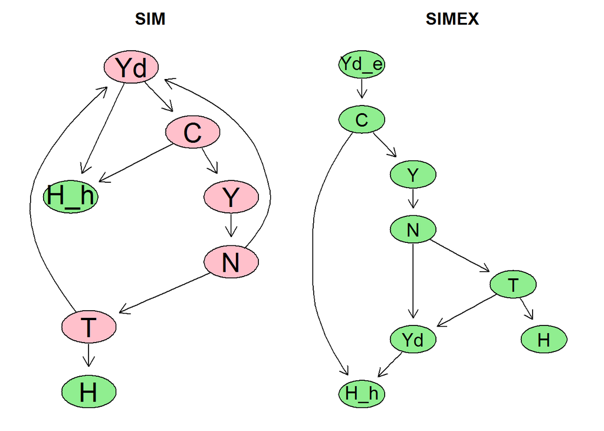

```r
simex<-sfc.model("SIMEX.txt",modelName="SIMplest model with expectation")
layout(matrix(c(1,2),1,2))
plot.dag(sim,main="SIM" )
plot.dag(simex,main="SIMEX" )
```

## In the case of a more complex model - Chapter 6

- We can generate the plots that allow us to delve into the actual structure of the system.
- Nodes that do not form a cycle are green while nodes that form a cycle in the system are pink.
- The Gauss-Seidel needs to be applied only for the cycles

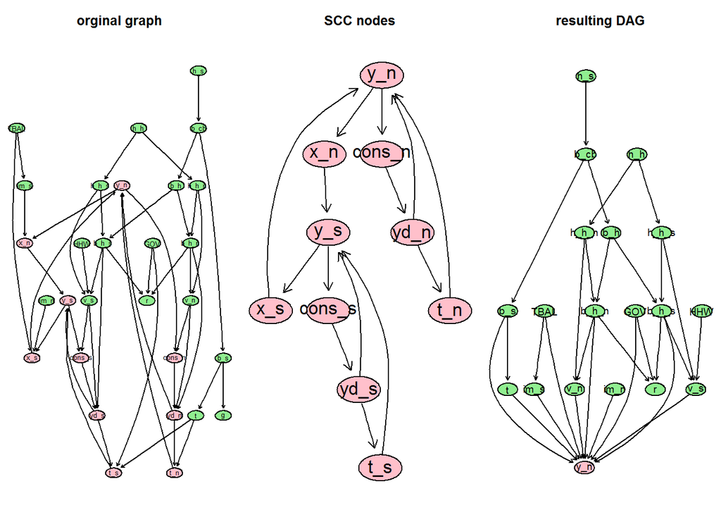

```r
ch6 <- sfc.model("ch6.txt",modelName="Chapter6_openmodel")
graphs = generate.DAG.collapse( adjacency = ch6$matrix )
par(mfrow = c(1,3))
# first plot the orgianl grpah
plot_graph_hierarchy( graphs$orginal_graph, main = "orginal graph" )
# plot hte nodes that form the strongly connected compoent
plot_graph_hierarchy( graphs$SCC_graph, main = "SCC nodes" )
# plot the result ing DAG when we take the condensation of the graph
plot_graph_hierarchy( graphs$DAG, main = "resulting DAG" )
```

## Systems of dependent vs independent equations

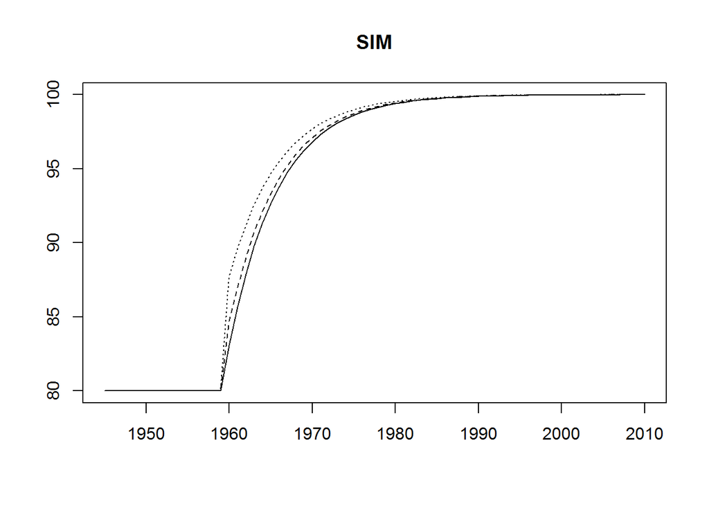

```r
datasimex<-simulate(simex)
init = datasimex$baseline[66,]
simex<-sfc.addScenario(simex,"G",25,1960,2010,init)
datasimex<-simulate(simex)
datasim<-simulate(sim)
init = datasim$baseline[66,]
sim<-sfc.addScenario(sim,"G",25,1960,2010,init)
datasim<-simulate(sim)
plot(sim$time,datasim$scenario_1[,"H"],type="l",xlab="",ylab="",main="SIM")
lines(sim$time,datasim$scenario_1[,"C"],lty=2)
lines(sim$time,datasim$scenario_1[,"Yd"],lty=3)
legend(x=1944,y=130,legend=c("Wealth","Consumption","Disposable Income"),
       lty=c(1,2,3),bty="n")
```

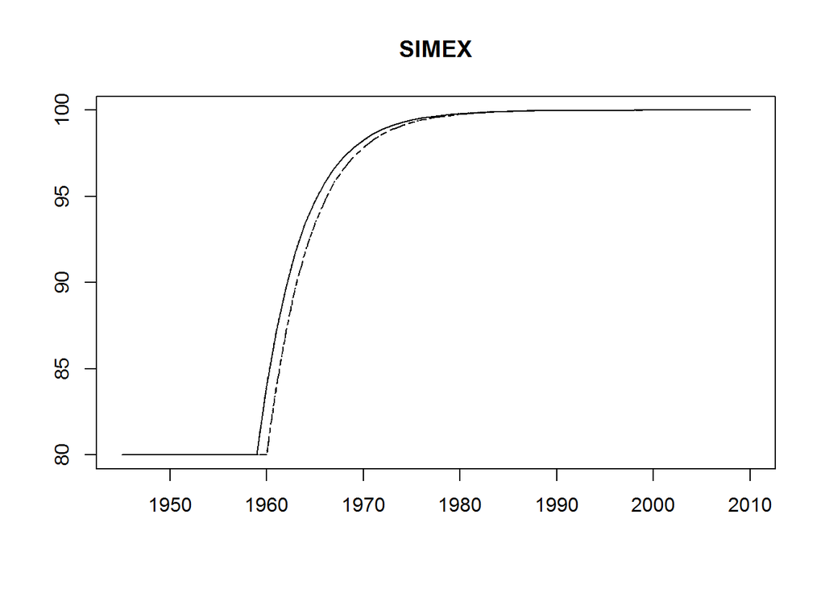

```r
plot(simex$time,datasimex$scenario_1[,"H"],type="l",xlab="",ylab="",main="SIMEX")
lines(simex$time,datasimex$scenario_1[,"C"],lty=2)
lines(simex$time,datasimex$scenario_1[,"Yd"],lty=3)
lines(simex$time,datasimex$scenario_1[,"Yd_e"],lty=4)
legend(x=1944,y=130,legend=c("Wealth","Consumption","Disposable Income",
                             "Expecetd Disposable Income"),lty=c(1,2,3,4),bty="n")
```

## Computational implications

Let’s see how much time it takes to run sim:

```r
ptm <- proc.time()
data1<-simulate(sim)
print(paste("Elapsed time is ",proc.time()[3]-ptm[3],"seconds"))
```

```
## [1] "Elapsed time is  4.79 seconds"
```

Now lets play with some of the parameters of the simulate function:

1. tolValue

```r
ptm <- proc.time()
data2<-simulate(sim,tolValue = 1e-3)
print(paste("Elapsed time is ",proc.time()[3]-ptm[3],"seconds"))
```

```
## [1] "Elapsed time is  0.259999999999998 seconds"
```

2. maxIter

```r
ptm <- proc.time()
data3<-simulate(sim, maxIter=10)
print(paste("Elapsed time is ",proc.time()[3]-ptm[3],"seconds"))
```

```
## [1] "Elapsed time is  0.330000000000002 seconds"
```

## Observing the results of the three simulations

```r
kable(round(t(data1$baseline[c(1,2,20,40,66),c("G","Y","T","Yd","C","H","H_h")]),digits=3))
```

|  | 1945 | 1946 | 1964 | 1984 | 2010 |
| --- | --- | --- | --- | --- | --- |
| G | 20 | 20.000 | 20.000 | 20.000 | 20.000 |
| Y | NA | 38.462 | 96.957 | 99.892 | 99.999 |
| T | NA | 7.692 | 19.391 | 19.978 | 20.000 |
| Yd | NA | 30.769 | 77.566 | 79.914 | 79.999 |
| C | NA | 18.462 | 76.957 | 79.892 | 79.999 |
| H | 0 | 12.308 | 76.653 | 79.882 | 79.998 |
| H_h | 0 | 12.308 | 76.653 | 79.882 | 79.998 |

```r
kable(round(t(data2$baseline[c(1,2,20,40,66),c("G","Y","T","Yd","C","H","H_h")]),digits=3))
```

|  | 1945 | 1946 | 1964 | 1984 | 2010 |
| --- | --- | --- | --- | --- | --- |
| G | 20 | 20.000 | 20.000 | 20.000 | 20.000 |
| Y | NA | 38.464 | 96.874 | 99.577 | 99.911 |
| T | NA | 7.693 | 19.369 | 19.909 | 19.980 |
| Yd | NA | 30.772 | 77.478 | 79.644 | 79.920 |
| C | NA | 18.460 | 76.870 | 79.566 | 79.917 |
| H | 0 | 12.308 | 76.745 | 81.506 | 82.795 |
| H_h | 0 | 12.303 | 76.569 | 79.535 | 79.922 |

```r
kable(round(t(data3$baseline[c(1,2,20,40,66),c("G","Y","T","Yd","C","H","H_h")]),digits=3))
```

|  | 1945 | 1946 | 1964 | 1984 | 2010 |
| --- | --- | --- | --- | --- | --- |
| G | 20 | 20.000 | 20.000 | 20.000 | 20.000 |
| Y | NA | 34.006 | 94.965 | 99.672 | 99.991 |
| T | NA | 5.978 | 18.970 | 19.933 | 19.998 |
| Yd | NA | 23.982 | 75.899 | 79.733 | 79.992 |
| C | NA | 14.136 | 74.878 | 79.666 | 79.990 |
| H | 0 | 14.094 | 91.289 | 97.979 | 98.432 |
| H_h | 0 | 9.554 | 74.332 | 79.631 | 79.989 |

## Block Gauss-Seidel

The order of equations matters, if first compute variables that do not depend on current period, this speeds the process. Define blocks of equation independent from the others.

```r
print(simex)
```

```
## $name
## [1] "SIMplest model with expectation"
##
## $simulated
## [1] FALSE
##
## $variables
##       name     initial value description
##  [1,] "Yd"     "0"           "1. EQUATIONS"
##  [2,] "T"      NA            ""
##  [3,] "C"      NA            ""
##  [4,] "H"      "0"           ""
##  [5,] "H_h"    "0"           ""
##  [6,] "Y"      NA            ""
##  [7,] "Yd_e"   NA            ""
##  [8,] "N"      NA            ""
##  [9,] "alpha1" "0.6"         "2. PARAMETERS"
## [10,] "alpha2" "0.4"         ""
## [11,] "theta"  "0.2"         ""
## [12,] "G"      "20"          "EXOGENOUS"
## [13,] "W"      "1"           ""
##
## $endogenous
##      name   initial value lag description
## [1,] "Yd"   "0"           "1" "1. EQUATIONS"
## [2,] "T"    NA            "0" ""
## [3,] "C"    NA            "0" ""
## [4,] "H"    "0"           "1" ""
## [5,] "H_h"  "0"           "1" ""
## [6,] "Y"    NA            "0" ""
## [7,] "Yd_e" NA            "0" ""
## [8,] "N"    NA            "0" ""
##
## $equations
##      endogenous value equation                   description
## [1,] "Yd"             "W*N-T"                    "1. EQUATIONS"
## [2,] "T"              "theta*W*N"                ""
## [3,] "C"              "alpha1*Yd_e+alpha2*H_h_1" ""
## [4,] "H"              "H_1+G-T"                  ""
## [5,] "H_h"            "H_h_1+Yd-C"               ""
```

[output cut: 58 more lines]

```
##
## $scenarios[[1]]$start
##           Yd            T            C            H          H_h
##     79.99996     19.99999     79.99995     79.99996     79.99996
##            Y         Yd_e            N       alpha1       alpha2
##     99.99995     79.99995     99.99995      0.60000      0.40000
##        theta            G            W iter block 1 iter block 2
##      0.20000     20.00000      1.00000      2.00000      2.00000
## iter block 3 iter block 4 iter block 5 iter block 6 iter block 7
##      2.00000      2.00000      2.00000      2.00000      2.00000
##
##
##
## attr(,"class")
## [1] "sfc"
```

## Simulation of SIMEX

```r
ptm <- proc.time()
dataex<-simulate(simex,tolValue = 1e-10)
print(paste("Elapsed time is ",proc.time()[3]-ptm[3],"seconds"))
```

```
## [1] "Elapsed time is  0.310000000000002 seconds"
```

## Results for SIMEX

```r
kable(round(t(dataex$baseline[c(1,2,20,40,66),c("G","Y","T","Yd","Yd_e","C","H","H_h")]),digits=3))
```

|  | 1945 | 1946 | 1964 | 1984 | 2010 |
| --- | --- | --- | --- | --- | --- |
| G | 20 | 20 | 20.000 | 20.000 | 20 |
| Y | NA | 20 | 98.559 | 99.983 | 100 |
| T | NA | 4 | 19.712 | 19.997 | 20 |
| Yd | 0 | 16 | 78.847 | 79.987 | 80 |
| Yd_e | NA | 0 | 78.559 | 79.983 | 80 |
| C | NA | 0 | 78.559 | 79.983 | 80 |
| H | 0 | 16 | 78.847 | 79.987 | 80 |
| H_h | 0 | 16 | 78.847 | 79.987 | 80 |

## Output data structure

- Output is a list of matrix where each element of the list are a scenario
- baseline
- scenario_i
- In the result matrix, there is a column indicating the number of iteration in the Gauss-Seidel algorithm per block of equations per period

```r
kable(dataex$baseline)
```

|  | Yd | T | C | H | H_h | Y | Yd_e | N | alpha1 | alpha2 | theta | G | W | iter block 1 | iter block 2 | iter block 3 | iter block 4 | iter block 5 | iter block 6 | iter block 7 |
| --- | --- | --- | --- | --- | --- | --- | --- | --- | --- | --- | --- | --- | --- | --- | --- | --- | --- | --- | --- | --- |
| 1945 | 0.00000 | NA | NA | 0.00000 | 0.00000 | NA | NA | NA | 0.6 | 0.4 | 0.2 | 20 | 1 | 0 | 0 | 0 | 0 | 0 | 0 | 0 |
| 1946 | 16.00000 | 4.00000 | 0.00000 | 16.00000 | 16.00000 | 20.00000 | 0.00000 | 20.00000 | 0.6 | 0.4 | 0.2 | 20 | 1 | 2 | 2 | 2 | 2 | 2 | 2 | 2 |
| 1947 | 28.80000 | 7.20000 | 16.00000 | 28.80000 | 28.80000 | 36.00000 | 16.00000 | 36.00000 | 0.6 | 0.4 | 0.2 | 20 | 1 | 2 | 2 | 2 | 2 | 2 | 2 | 2 |
| 1948 | 39.04000 | 9.76000 | 28.80000 | 39.04000 | 39.04000 | 48.80000 | 28.80000 | 48.80000 | 0.6 | 0.4 | 0.2 | 20 | 1 | 2 | 2 | 2 | 2 | 2 | 2 | 2 |
| 1949 | 47.23200 | 11.80800 | 39.04000 | 47.23200 | 47.23200 | 59.04000 | 39.04000 | 59.04000 | 0.6 | 0.4 | 0.2 | 20 | 1 | 2 | 2 | 2 | 2 | 2 | 2 | 2 |
| 1950 | 53.78560 | 13.44640 | 47.23200 | 53.78560 | 53.78560 | 67.23200 | 47.23200 | 67.23200 | 0.6 | 0.4 | 0.2 | 20 | 1 | 2 | 2 | 2 | 2 | 2 | 2 | 2 |
| 1951 | 59.02848 | 14.75712 | 53.78560 | 59.02848 | 59.02848 | 73.78560 | 53.78560 | 73.78560 | 0.6 | 0.4 | 0.2 | 20 | 1 | 2 | 2 | 2 | 2 | 2 | 2 | 2 |
| 1952 | 63.22278 | 15.80570 | 59.02848 | 63.22278 | 63.22278 | 79.02848 | 59.02848 | 79.02848 | 0.6 | 0.4 | 0.2 | 20 | 1 | 2 | 2 | 2 | 2 | 2 | 2 | 2 |
| 1953 | 66.57823 | 16.64456 | 63.22278 | 66.57823 | 66.57823 | 83.22278 | 63.22278 | 83.22278 | 0.6 | 0.4 | 0.2 | 20 | 1 | 2 | 2 | 2 | 2 | 2 | 2 | 2 |
| 1954 | 69.26258 | 17.31565 | 66.57823 | 69.26258 | 69.26258 | 86.57823 | 66.57823 | 86.57823 | 0.6 | 0.4 | 0.2 | 20 | 1 | 2 | 2 | 2 | 2 | 2 | 2 | 2 |
| 1955 | 71.41007 | 17.85252 | 69.26258 | 71.41007 | 71.41007 | 89.26258 | 69.26258 | 89.26258 | 0.6 | 0.4 | 0.2 | 20 | 1 | 2 | 2 | 2 | 2 | 2 | 2 | 2 |
| 1956 | 73.12805 | 18.28201 | 71.41007 | 73.12805 | 73.12805 | 91.41007 | 71.41007 | 91.41007 | 0.6 | 0.4 | 0.2 | 20 | 1 | 2 | 2 | 2 | 2 | 2 | 2 | 2 |
| 1957 | 74.50244 | 18.62561 | 73.12805 | 74.50244 | 74.50244 | 93.12805 | 73.12805 | 93.12805 | 0.6 | 0.4 | 0.2 | 20 | 1 | 2 | 2 | 2 | 2 | 2 | 2 | 2 |
| 1958 | 75.60195 | 18.90049 | 74.50244 | 75.60195 | 75.60195 | 94.50244 | 74.50244 | 94.50244 | 0.6 | 0.4 | 0.2 | 20 | 1 | 2 | 2 | 2 | 2 | 2 | 2 | 2 |
| 1959 | 76.48156 | 19.12039 | 75.60195 | 76.48156 | 76.48156 | 95.60195 | 75.60195 | 95.60195 | 0.6 | 0.4 | 0.2 | 20 | 1 | 2 | 2 | 2 | 2 | 2 | 2 | 2 |
| 1960 | 77.18525 | 19.29631 | 76.48156 | 77.18525 | 77.18525 | 96.48156 | 76.48156 | 96.48156 | 0.6 | 0.4 | 0.2 | 20 | 1 | 2 | 2 | 2 | 2 | 2 | 2 | 2 |
| 1961 | 77.74820 | 19.43705 | 77.18525 | 77.74820 | 77.74820 | 97.18525 | 77.18525 | 97.18525 | 0.6 | 0.4 | 0.2 | 20 | 1 | 2 | 2 | 2 | 2 | 2 | 2 | 2 |
| 1962 | 78.19856 | 19.54964 | 77.74820 | 78.19856 | 78.19856 | 97.74820 | 77.74820 | 97.74820 | 0.6 | 0.4 | 0.2 | 20 | 1 | 2 | 2 | 2 | 2 | 2 | 2 | 2 |
| 1963 | 78.55885 | 19.63971 | 78.19856 | 78.55885 | 78.55885 | 98.19856 | 78.19856 | 98.19856 | 0.6 | 0.4 | 0.2 | 20 | 1 | 2 | 2 | 2 | 2 | 2 | 2 | 2 |
| 1964 | 78.84708 | 19.71177 | 78.55885 | 78.84708 | 78.84708 | 98.55885 | 78.55885 | 98.55885 | 0.6 | 0.4 | 0.2 | 20 | 1 | 2 | 2 | 2 | 2 | 2 | 2 | 2 |
| 1965 | 79.07766 | 19.76942 | 78.84708 | 79.07766 | 79.07766 | 98.84708 | 78.84708 | 98.84708 | 0.6 | 0.4 | 0.2 | 20 | 1 | 2 | 2 | 2 | 2 | 2 | 2 | 2 |
| 1966 | 79.26213 | 19.81553 | 79.07766 | 79.26213 | 79.26213 | 99.07766 | 79.07766 | 99.07766 | 0.6 | 0.4 | 0.2 | 20 | 1 | 2 | 2 | 2 | 2 | 2 | 2 | 2 |
| 1967 | 79.40970 | 19.85243 | 79.26213 | 79.40970 | 79.40970 | 99.26213 | 79.26213 | 99.26213 | 0.6 | 0.4 | 0.2 | 20 | 1 | 2 | 2 | 2 | 2 | 2 | 2 | 2 |
| 1968 | 79.52776 | 19.88194 | 79.40970 | 79.52776 | 79.52776 | 99.40970 | 79.40970 | 99.40970 | 0.6 | 0.4 | 0.2 | 20 | 1 | 2 | 2 | 2 | 2 | 2 | 2 | 2 |
| 1969 | 79.62221 | 19.90555 | 79.52776 | 79.62221 | 79.62221 | 99.52776 | 79.52776 | 99.52776 | 0.6 | 0.4 | 0.2 | 20 | 1 | 2 | 2 | 2 | 2 | 2 | 2 | 2 |
| 1970 | 79.69777 | 19.92444 | 79.62221 | 79.69777 | 79.69777 | 99.62221 | 79.62221 | 99.62221 | 0.6 | 0.4 | 0.2 | 20 | 1 | 2 | 2 | 2 | 2 | 2 | 2 | 2 |
| 1971 | 79.75821 | 19.93955 | 79.69777 | 79.75821 | 79.75821 | 99.69777 | 79.69777 | 99.69777 | 0.6 | 0.4 | 0.2 | 20 | 1 | 2 | 2 | 2 | 2 | 2 | 2 | 2 |
| 1972 | 79.80657 | 19.95164 | 79.75821 | 79.80657 | 79.80657 | 99.75821 | 79.75821 | 99.75821 | 0.6 | 0.4 | 0.2 | 20 | 1 | 2 | 2 | 2 | 2 | 2 | 2 | 2 |
| 1973 | 79.84526 | 19.96131 | 79.80657 | 79.84526 | 79.84526 | 99.80657 | 79.80657 | 99.80657 | 0.6 | 0.4 | 0.2 | 20 | 1 | 2 | 2 | 2 | 2 | 2 | 2 | 2 |
| 1974 | 79.87621 | 19.96905 | 79.84526 | 79.87621 | 79.87621 | 99.84526 | 79.84526 | 99.84526 | 0.6 | 0.4 | 0.2 | 20 | 1 | 2 | 2 | 2 | 2 | 2 | 2 | 2 |
| 1975 | 79.90096 | 19.97524 | 79.87621 | 79.90096 | 79.90096 | 99.87621 | 79.87621 | 99.87621 | 0.6 | 0.4 | 0.2 | 20 | 1 | 2 | 2 | 2 | 2 | 2 | 2 | 2 |
| 1976 | 79.92077 | 19.98019 | 79.90096 | 79.92077 | 79.92077 | 99.90096 | 79.90096 | 99.90096 | 0.6 | 0.4 | 0.2 | 20 | 1 | 2 | 2 | 2 | 2 | 2 | 2 | 2 |
| 1977 | 79.93662 | 19.98415 | 79.92077 | 79.93662 | 79.93662 | 99.92077 | 79.92077 | 99.92077 | 0.6 | 0.4 | 0.2 | 20 | 1 | 2 | 2 | 2 | 2 | 2 | 2 | 2 |
| 1978 | 79.94929 | 19.98732 | 79.93662 | 79.94929 | 79.94929 | 99.93662 | 79.93662 | 99.93662 | 0.6 | 0.4 | 0.2 | 20 | 1 | 2 | 2 | 2 | 2 | 2 | 2 | 2 |
| 1979 | 79.95944 | 19.98986 | 79.94929 | 79.95944 | 79.95944 | 99.94929 | 79.94929 | 99.94929 | 0.6 | 0.4 | 0.2 | 20 | 1 | 2 | 2 | 2 | 2 | 2 | 2 | 2 |
| 1980 | 79.96755 | 19.99189 | 79.95944 | 79.96755 | 79.96755 | 99.95944 | 79.95944 | 99.95944 | 0.6 | 0.4 | 0.2 | 20 | 1 | 2 | 2 | 2 | 2 | 2 | 2 | 2 |
| 1981 | 79.97404 | 19.99351 | 79.96755 | 79.97404 | 79.97404 | 99.96755 | 79.96755 | 99.96755 | 0.6 | 0.4 | 0.2 | 20 | 1 | 2 | 2 | 2 | 2 | 2 | 2 | 2 |
| 1982 | 79.97923 | 19.99481 | 79.97404 | 79.97923 | 79.97923 | 99.97404 | 79.97404 | 99.97404 | 0.6 | 0.4 | 0.2 | 20 | 1 | 2 | 2 | 2 | 2 | 2 | 2 | 2 |
| 1983 | 79.98338 | 19.99585 | 79.97923 | 79.98338 | 79.98338 | 99.97923 | 79.97923 | 99.97923 | 0.6 | 0.4 | 0.2 | 20 | 1 | 2 | 2 | 2 | 2 | 2 | 2 | 2 |
| 1984 | 79.98671 | 19.99668 | 79.98338 | 79.98671 | 79.98671 | 99.98338 | 79.98338 | 99.98338 | 0.6 | 0.4 | 0.2 | 20 | 1 | 2 | 2 | 2 | 2 | 2 | 2 | 2 |
| 1985 | 79.98937 | 19.99734 | 79.98671 | 79.98937 | 79.98937 | 99.98671 | 79.98671 | 99.98671 | 0.6 | 0.4 | 0.2 | 20 | 1 | 2 | 2 | 2 | 2 | 2 | 2 | 2 |
| 1986 | 79.99149 | 19.99787 | 79.98937 | 79.99149 | 79.99149 | 99.98937 | 79.98937 | 99.98937 | 0.6 | 0.4 | 0.2 | 20 | 1 | 2 | 2 | 2 | 2 | 2 | 2 | 2 |
| 1987 | 79.99319 | 19.99830 | 79.99149 | 79.99319 | 79.99319 | 99.99149 | 79.99149 | 99.99149 | 0.6 | 0.4 | 0.2 | 20 | 1 | 2 | 2 | 2 | 2 | 2 | 2 | 2 |
| 1988 | 79.99456 | 19.99864 | 79.99319 | 79.99456 | 79.99456 | 99.99319 | 79.99319 | 99.99319 | 0.6 | 0.4 | 0.2 | 20 | 1 | 2 | 2 | 2 | 2 | 2 | 2 | 2 |
| 1989 | 79.99564 | 19.99891 | 79.99456 | 79.99564 | 79.99564 | 99.99456 | 79.99456 | 99.99456 | 0.6 | 0.4 | 0.2 | 20 | 1 | 2 | 2 | 2 | 2 | 2 | 2 | 2 |
| 1990 | 79.99652 | 19.99913 | 79.99564 | 79.99652 | 79.99652 | 99.99564 | 79.99564 | 99.99564 | 0.6 | 0.4 | 0.2 | 20 | 1 | 2 | 2 | 2 | 2 | 2 | 2 | 2 |
| 1991 | 79.99721 | 19.99930 | 79.99652 | 79.99721 | 79.99721 | 99.99652 | 79.99652 | 99.99652 | 0.6 | 0.4 | 0.2 | 20 | 1 | 2 | 2 | 2 | 2 | 2 | 2 | 2 |
| 1992 | 79.99777 | 19.99944 | 79.99721 | 79.99777 | 79.99777 | 99.99721 | 79.99721 | 99.99721 | 0.6 | 0.4 | 0.2 | 20 | 1 | 2 | 2 | 2 | 2 | 2 | 2 | 2 |
| 1993 | 79.99822 | 19.99955 | 79.99777 | 79.99822 | 79.99822 | 99.99777 | 79.99777 | 99.99777 | 0.6 | 0.4 | 0.2 | 20 | 1 | 2 | 2 | 2 | 2 | 2 | 2 | 2 |
| 1994 | 79.99857 | 19.99964 | 79.99822 | 79.99857 | 79.99857 | 99.99822 | 79.99822 | 99.99822 | 0.6 | 0.4 | 0.2 | 20 | 1 | 2 | 2 | 2 | 2 | 2 | 2 | 2 |
| 1995 | 79.99886 | 19.99971 | 79.99857 | 79.99886 | 79.99886 | 99.99857 | 79.99857 | 99.99857 | 0.6 | 0.4 | 0.2 | 20 | 1 | 2 | 2 | 2 | 2 | 2 | 2 | 2 |
| 1996 | 79.99909 | 19.99977 | 79.99886 | 79.99909 | 79.99909 | 99.99886 | 79.99886 | 99.99886 | 0.6 | 0.4 | 0.2 | 20 | 1 | 2 | 2 | 2 | 2 | 2 | 2 | 2 |
| 1997 | 79.99927 | 19.99982 | 79.99909 | 79.99927 | 79.99927 | 99.99909 | 79.99909 | 99.99909 | 0.6 | 0.4 | 0.2 | 20 | 1 | 2 | 2 | 2 | 2 | 2 | 2 | 2 |
| 1998 | 79.99942 | 19.99985 | 79.99927 | 79.99942 | 79.99942 | 99.99927 | 79.99927 | 99.99927 | 0.6 | 0.4 | 0.2 | 20 | 1 | 2 | 2 | 2 | 2 | 2 | 2 | 2 |
| 1999 | 79.99953 | 19.99988 | 79.99942 | 79.99953 | 79.99953 | 99.99942 | 79.99942 | 99.99942 | 0.6 | 0.4 | 0.2 | 20 | 1 | 2 | 2 | 2 | 2 | 2 | 2 | 2 |
| 2000 | 79.99963 | 19.99991 | 79.99953 | 79.99963 | 79.99963 | 99.99953 | 79.99953 | 99.99953 | 0.6 | 0.4 | 0.2 | 20 | 1 | 2 | 2 | 2 | 2 | 2 | 2 | 2 |
| 2001 | 79.99970 | 19.99993 | 79.99963 | 79.99970 | 79.99970 | 99.99963 | 79.99963 | 99.99963 | 0.6 | 0.4 | 0.2 | 20 | 1 | 2 | 2 | 2 | 2 | 2 | 2 | 2 |
| 2002 | 79.99976 | 19.99994 | 79.99970 | 79.99976 | 79.99976 | 99.99970 | 79.99970 | 99.99970 | 0.6 | 0.4 | 0.2 | 20 | 1 | 2 | 2 | 2 | 2 | 2 | 2 | 2 |
| 2003 | 79.99981 | 19.99995 | 79.99976 | 79.99981 | 79.99981 | 99.99976 | 79.99976 | 99.99976 | 0.6 | 0.4 | 0.2 | 20 | 1 | 2 | 2 | 2 | 2 | 2 | 2 | 2 |
| 2004 | 79.99985 | 19.99996 | 79.99981 | 79.99985 | 79.99985 | 99.99981 | 79.99981 | 99.99981 | 0.6 | 0.4 | 0.2 | 20 | 1 | 2 | 2 | 2 | 2 | 2 | 2 | 2 |
| 2005 | 79.99988 | 19.99997 | 79.99985 | 79.99988 | 79.99988 | 99.99985 | 79.99985 | 99.99985 | 0.6 | 0.4 | 0.2 | 20 | 1 | 2 | 2 | 2 | 2 | 2 | 2 | 2 |
| 2006 | 79.99990 | 19.99998 | 79.99988 | 79.99990 | 79.99990 | 99.99988 | 79.99988 | 99.99988 | 0.6 | 0.4 | 0.2 | 20 | 1 | 2 | 2 | 2 | 2 | 2 | 2 | 2 |
| 2007 | 79.99992 | 19.99998 | 79.99990 | 79.99992 | 79.99992 | 99.99990 | 79.99990 | 99.99990 | 0.6 | 0.4 | 0.2 | 20 | 1 | 2 | 2 | 2 | 2 | 2 | 2 | 2 |
| 2008 | 79.99994 | 19.99998 | 79.99992 | 79.99994 | 79.99994 | 99.99992 | 79.99992 | 99.99992 | 0.6 | 0.4 | 0.2 | 20 | 1 | 2 | 2 | 2 | 2 | 2 | 2 | 2 |
| 2009 | 79.99995 | 19.99999 | 79.99994 | 79.99995 | 79.99995 | 99.99994 | 79.99994 | 99.99994 | 0.6 | 0.4 | 0.2 | 20 | 1 | 2 | 2 | 2 | 2 | 2 | 2 | 2 |
| 2010 | 79.99996 | 19.99999 | 79.99995 | 79.99996 | 79.99996 | 99.99995 | 79.99995 | 99.99995 | 0.6 | 0.4 | 0.2 | 20 | 1 | 2 | 2 | 2 | 2 | 2 | 2 | 2 |

## Checking the number of iteractions

- For sim, no simulate parameters:

```r
kable(round(t(data1$baseline[c(1,2,20,40,66),c("iter block 1")]),digits=3))
```

[output not shown]

```r
kable(round(t(data2$baseline[c(1,2,20,40,66),c("iter block 1")]),digits=3))
```

[output not shown]

```r
kable(round(t(data2$baseline[c(1,2,20,40,66),c("iter block 1")]),digits=3))
```

[output not shown]

```r
kable(round(t(dataex$baseline[c(1,2,20,40,66),c("iter block 1","iter block 2","iter block 3","iter block 4","iter block 5","iter block 6","iter block 7")]),digits=3))
```

|  | 1945 | 1946 | 1964 | 1984 | 2010 |
| --- | --- | --- | --- | --- | --- |
| iter block 1 | 0 | 2 | 2 | 2 | 2 |
| iter block 2 | 0 | 2 | 2 | 2 | 2 |
| iter block 3 | 0 | 2 | 2 | 2 | 2 |
| iter block 4 | 0 | 2 | 2 | 2 | 2 |
| iter block 5 | 0 | 2 | 2 | 2 | 2 |
| iter block 6 | 0 | 2 | 2 | 2 | 2 |
| iter block 7 | 0 | 2 | 2 | 2 | 2 |

## Buffer stocks, using model PC

- Observe the buffer role of money, in case of random shocks applied to expected disposable income
- we need to modify slightly model pc and change the equations determining
- consumption,
- demand for bonds and money,
- expectations on income and wealth

```r
pc<-sfc.model("PC.txt",modelName="Portfolio Choice Model")
# Changing Existing equations
pcRand<-sfc.editEqus(pc,list(
  list(var="cons",eq="alpha1*yde+alpha2*v(-1)"),
  list(var="b_h",eq="ve*(lambda0 + lambda1*r - lambda2*(yde/ve))")))

# Adding equations
pcRand<-sfc.addEqus(pcRand,list(
  list(var="yde",eq="yd(-1)*(1+rnorm(1,sd=0.1))",desc="Expected disposable income depending on random shocks"),
  list(var="h_d",eq="ve-b_h",desc="Money demand"),
  list(var="ve",eq="v(-1)+yde-cons",desc="Expected disposable income")))

# Adding the initial value of yd (to be used in the expectation function)
pcRand<-sfc.editVar(pcRand,var="yd",init=86.48648)

# Checking if the model is complete
pcRand<-sfc.check(pcRand)
```

- Before simulatin the model, let’s have a look at how the graph of the model has changed:

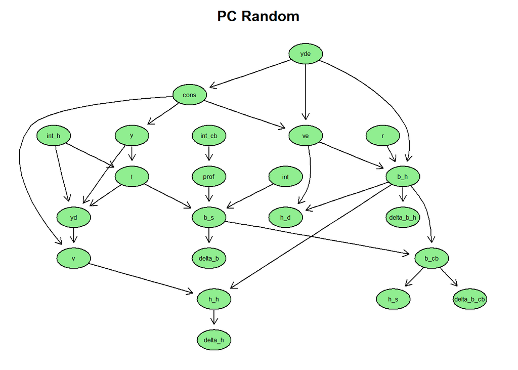

```r
plot.dag(pcRand,main="PC Random" )
```

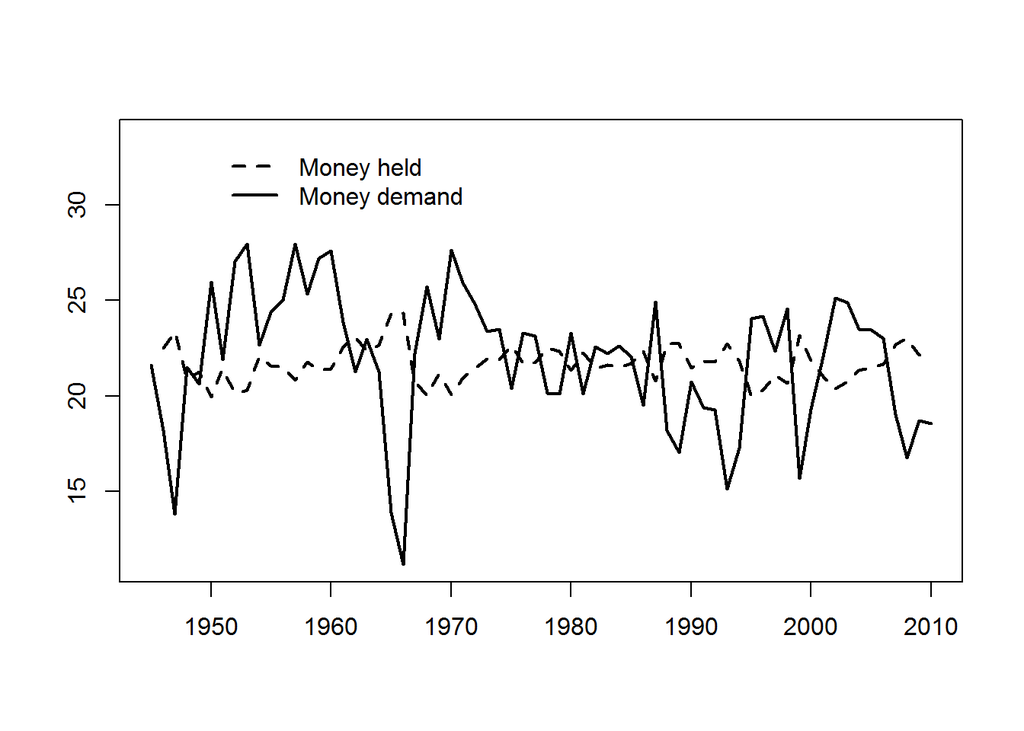

```r
datapcRand<-simulate(pcRand,maxIter=2)
plot(pcRand$time,datapcRand$baseline[,"h_h"],type="l",xlab="",ylab="",lty=1,lwd=2,
     ylim=c(1*min(datapcRand$baseline[,c("h_h","h_d")],na.rm=T),
            1.2*max(datapcRand$baseline[,c("h_h","h_d")],na.rm=T)))
lines(pcRand$time,datapcRand$baseline[,"h_d"],lty=2,lwd=2)
legend(x=1950,y=1.2*max(datapcRand$baseline[,c("h_h","h_d")],na.rm=T),
       legend=c("Money held","Money demand"),lty=c(2,1),lwd=2,bty="n")
```

- This graph highlights the buffer role of certain stocks in PK-SFC models.
- expectations are incorrect
- demand might not be equal to supply in any market
- one stock will not be equal to the targeted level, as highlighted by Foley (1975), in a model without perfect foresight you need a buffer stock in order to obtain equilibrium between demand and supply.
- The role of buffer stocks in PK-SFC model is thus fundamental and is at the hart of the approach used by Godley (1999) in his seven unsustainable processes. - It is by observing the dynamics of certain stock-flow norms that you are able to observe the unsustainable processes evolving in an economy, because stocks precisely absorb disequilibrium.

## Sankey Diagrams

```r
plot.sankey(as.data.frame(datapcRand$baseline),filename="TFM_PC.csv",period=2,outputfile="SANKEY.html")
```

```r
htmltools::includeHTML("SANKEY.html")
```

[interactive chart not shown]

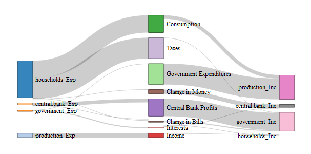

# References

Foley, D. 1975. “On Two Specifications of Asset Equilibrium in Macroeconomic Models.” *Journal of Political Economy* 83 (2).

Godley, Wynne. 1999. “Seven Unsustainable Processes: Medium-Term Prospects and Policies for the United States and the World.” Strategic Analysis. The Levy Economic Institute of Bard College.